# Analysis of variance (ANOVA)

Qiusheng Wu

## Hypothesis Testing

### Problem

Test whether employees experience different levels of stress under normal, announced layoff, and during layoff.

### Solution

```r
A <- c(2,3,7,2,6)
B <- c(10,8,7,5,10)
C <- c(10,13,14,13,15)
stress <- c(A,B,C)
group <- c(rep("A",5),rep("B",5),rep("C",5))
df <- data.frame(stress,group)
m <- aov(stress~group,data = df)
m
```

```
Call:
   aov(formula = stress ~ group, data = df)

Terms:
                   group Residuals
Sum of Squares  203.3333   54.0000
Deg. of Freedom        2        12

Residual standard error: 2.12132
Estimated effects may be unbalanced
```

```r
summary(m)
```

```
            Df Sum Sq Mean Sq F value   Pr(>F)
group        2  203.3   101.7   22.59 8.54e-05 ***
Residuals   12   54.0     4.5
---
Signif. codes:  0 ‘***’ 0.001 ‘**’ 0.01 ‘*’ 0.05 ‘.’ 0.1 ‘ ’ 1
```

```r
TukeyHSD(m)
```

```
  Tukey multiple comparisons of means
    95% family-wise confidence level

Fit: aov(formula = stress ~ group, data = df)

$group
    diff       lwr       upr     p adj
B-A    4 0.4206853  7.579315 0.0286585
C-A    9 5.4206853 12.579315 0.0000598
C-B    5 1.4206853  8.579315 0.0075279
```

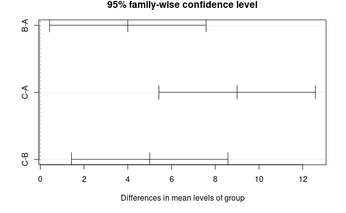

```r
plot(TukeyHSD(m))
```

```r
qf(0.95,df1 = 2,df2 = 12)
```

```
[1] 3.885294
```

```r
pf(22.59,df1 = 2,df2 = 12,lower.tail = FALSE)
```

```
[1] 8.543239e-05
```

```r
s <- oneway.test(stress~group, data = df, var.equal = TRUE)
s
```

```
    One-way analysis of means

data:  stress and group
F = 22.593, num df = 2, denom df = 12, p-value = 8.539e-05
```

```r
summary(s)
```

```
          Length Class  Mode
statistic 1      -none- numeric
parameter 2      -none- numeric
p.value   1      -none- numeric
method    1      -none- character
data.name 1      -none- character
```

```r
str(s)
```

```
List of 5
 $ statistic: Named num 22.6
  ..- attr(*, "names")= chr "F"
 $ parameter: Named num [1:2] 2 12
  ..- attr(*, "names")= chr [1:2] "num df" "denom df"
 $ p.value  : num 8.54e-05
 $ method   : chr "One-way analysis of means"
 $ data.name: chr "stress and group"
 - attr(*, "class")= chr "htest"
```

## Testing for Normality

### Problem

You want a statistical test to determine whether your data sample is from a normally distributed population.

### Solution

Use the shapiro.test function:

`shapiro.test(x)`

The output includes a p-value. Conventionally, p < 0.05 indicates that the population is likely not normally distributed whereas p > 0.05 provides no such evidence.

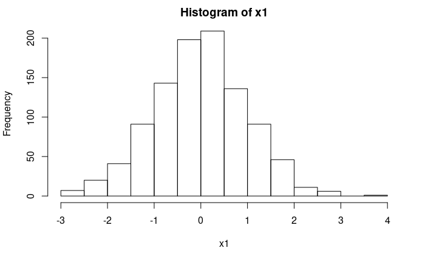

```r
x1 <- rnorm(n = 1000)
hist(x1)
```

```r
shapiro.test(x1)
```

```
    Shapiro-Wilk normality test

data:  x1
W = 0.99836, p-value = 0.4656
```

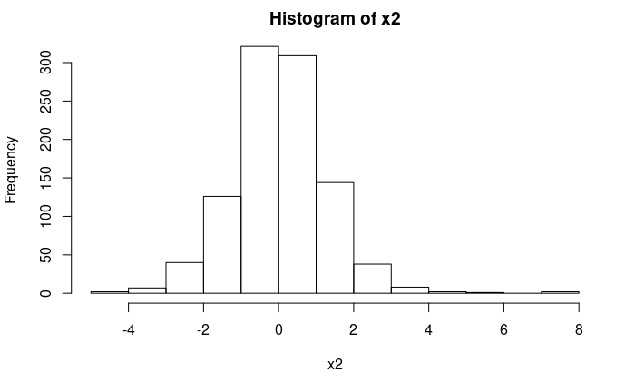

```r
x2 <- rt(1000,df = 5)
hist(x2)
```

```r
shapiro.test(x2)
```

```
    Shapiro-Wilk normality test

data:  x2
W = 0.97518, p-value = 4.809e-12
```

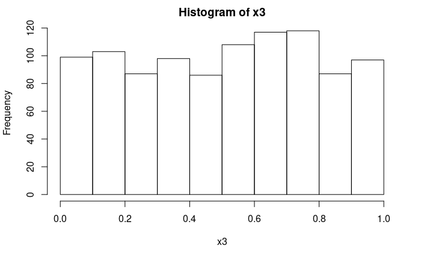

```r
x3 <- runif(1000)
hist(x3)
```

```r
shapiro.test(x3)
```

```
    Shapiro-Wilk normality test

data:  x3
W = 0.95612, p-value < 2.2e-16
```

## Testing for Homogeneity

### Problem

The population variances are assumed equal for each category (`leveneTest()` in `car` package)

### Solution

Sample data with homogeneity

```r
#Load packages
if (!require(car)) {install.packages("car")}
library(reshape2)
library(car)
#Creating example data
sample1 <- rnorm(20)
sample2 <- rnorm(20)
#Combine data
sample <- as.data.frame(cbind(sample1, sample2))
#Melt data
dataset <- melt(sample)
print(dataset)
```

| variable | value |
| --- | --- |
| sample1 | 1.03808250 |
| sample1 | 0.39139190 |
| sample1 | -0.22016480 |
| sample1 | -1.75754431 |
| sample1 | 1.98441790 |
| sample1 | 0.58378517 |
| sample1 | 2.24514317 |
| sample1 | -1.96804532 |
| sample1 | -1.10073640 |
| sample1 | -1.14552389 |

[output cut: 30 more lines]

```r
#Compute test
leveneTest(value ~ variable, dataset)
```

```
Levene's Test for Homogeneity of Variance (center = median)
      Df F value Pr(>F)
group  1  0.0615 0.8054
      38
```

Sample data without homogeneity

```r
#Load packages
library(reshape2)
library(car)
#Creating example data
sample1 <- rnorm(20)
sample2 <- rnorm(20,mean = 100,sd = 10)
#Combine data
sample <- as.data.frame(cbind(sample1, sample2))
#Melt data
dataset <- melt(sample)
print(dataset)
```

| variable | value |
| --- | --- |
| sample1 | 0.71233061 |
| sample1 | -0.09741643 |
| sample1 | -0.42735516 |
| sample1 | 0.54824003 |
| sample1 | -1.07095798 |
| sample1 | -1.67057161 |
| sample1 | -2.30898560 |
| sample1 | -1.85944523 |
| sample1 | -0.15909403 |
| sample1 | -0.06377987 |

[output cut: 30 more lines]

```r
#Compute test
leveneTest(value ~ variable, dataset)
```

```
Levene's Test for Homogeneity of Variance (center = median)
      Df F value   Pr(>F)
group  1   15.41 0.000352 ***
      38
---
Signif. codes:  0 ‘***’ 0.001 ‘**’ 0.01 ‘*’ 0.05 ‘.’ 0.1 ‘ ’ 1
```

## Kruskal-Wallis Test

### Problem

If the data deviate drastically from the assumptions, or if the p-value is close to $\alpha$, then an alternative test that does not rely on the assumptions might be considered. Tests that do not make assumptions regarding how the underlying data are distributed are called **nonparametric tests**. The nonparametric test for testing the equality of means for two or more categories is the Kruskal–Wallis test. There is another set of circumstances for which the Kruskal–Wallis test is useful for testing hypotheses about a set of means – namely when only ranked (i.e., ordinal) data are available. In such situations, there is insufficient information to use ANOVA, which requires interval or ratio level data. (Recall that with interval and ratio data the magnitude of the difference between the observations is meaningful.)

### Solution

For example, we want to know if the air quality vaires significantly by month?

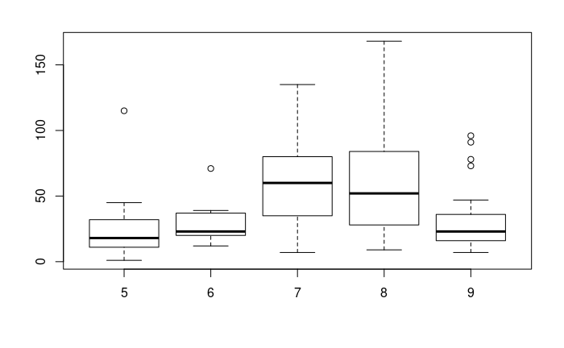

```r
library(graphics)
df <- airquality
boxplot(Ozone ~ Month, data = df)
```

```r
kruskal.test(Ozone ~ Month, data = df)
```

```
    Kruskal-Wallis rank sum test

data:  Ozone by Month
Kruskal-Wallis chi-squared = 29.267, df = 4, p-value = 6.901e-06
```

## Chi-squared Distribution

### Solution

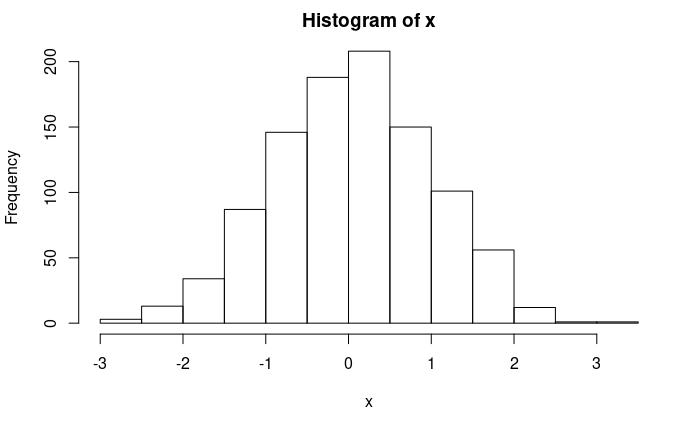

```r
x <- rnorm(1000)
hist(x)
```

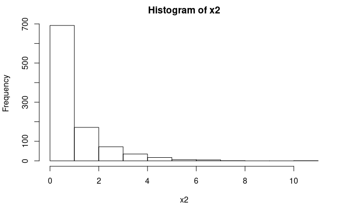

```r
x2 <- x^2
hist(x2)
```

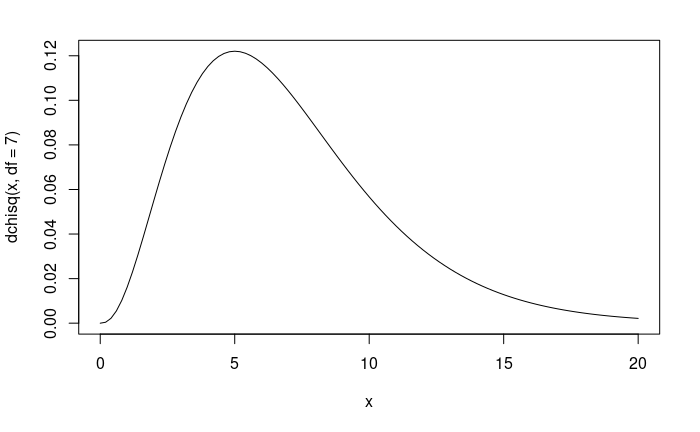

```r
curve(dchisq(x, df = 7), from = 0, to = 20)
```

```r
qchisq(.95, df = 7) # 7 degrees of freedom
```

```
[1] 14.06714
```

## F Distribution

### Problem

Find the 95th percentile of the F distribution with (5, 2) degrees of freedom.

### Solution

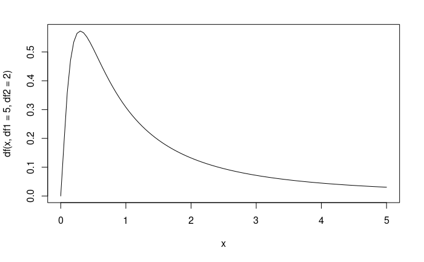

```r
curve(df(x,df1 = 5,df2 = 2),from = 0,to = 5)
```

```r
qf(.95, df1 = 5, df2 = 2)
```

```
[1] 19.29641
```